# QK Box 12.4

Skrip et al (2016) studied the effects of dietary antioxidants and exercise on the allocation of nutrients to eggs in zebra finches (*Taeniopygia guttata*). We will focus on one aspect of their study, how the order of egg laying affected the mass of the eggs. Mating pairs of finches were allocated randomly to two diet groups (supplemented with high antioxidant food, no supplement) and two exercise groups (additional flight exercise, no additional exercise). The finches laid between one and nine eggs but few laid more than five and pairs that laid only one egg don’t provide enough information for fitting a regression between order and egg mass. So we will analyze egg mass as the response variable from pairs that laid between two and five eggs. The between-subjects component was a two factor (diet and exercise) crossed design with pairs as subjects, and egg order (within each pair) was the within-subjects factor.

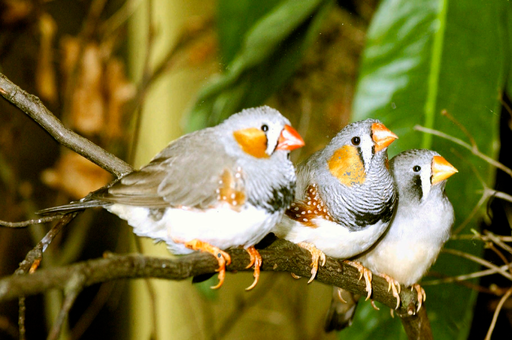

Link to [paper](http://doi.org/10.1242/jeb.137802)

### Preliminaries

First, load the required packages (afex, car, lattice, lme4, lmerTest, nlme, VCA, ez, emmeans, Rmisc, MuMIn)

Import skrip data file

```r
skrip <- read.csv("../data/skrip.csv")
skrip
```

| date | pair | female | male | order | diet | exercise | group | wmass | yolkmass | albmass | yolkperc | lutein | vite |
| --- | --- | --- | --- | --- | --- | --- | --- | --- | --- | --- | --- | --- | --- |
| 1/9/2012 | a | 521 | 507 | 1 | con | none | con_none | 1.113 | 0.352 | 0.565 | 31.6 | 104.7 | 235.5 |
| 1/9/2012 | a | 521 | 507 | 2 | con | none | con_none | 1.087 | 0.342 | 0.590 | 31.4 | 82.8 | 201.8 |
| 2/9/2012 | a | 521 | 507 | 3 | con | none | con_none | NA | 0.360 | 0.521 | NA | 65.2 | 128.2 |
| 3/9/2012 | a | 521 | 507 | 4 | con | none | con_none | 1.071 | 0.367 | 0.478 | 34.3 | 57.3 | 128.6 |
| 10/9/2012 | b | 535 | 517 | 1 | con | none | con_none | 1.030 | 0.305 | 0.420 | 29.6 | 85.7 | 126.9 |
| 11/9/2012 | b | 535 | 517 | 2 | con | none | con_none | NA | NA | NA | NA | NA | NA |
| 12/9/2012 | b | 535 | 517 | 3 | con | none | con_none | 0.966 | 0.305 | 0.499 | 31.5 | 62.6 | 84.2 |
| 13/9/2012 | b | 535 | 517 | 4 | con | none | con_none | 1.045 | 0.313 | 0.606 | 30.0 | 49.1 | 68.8 |
| 14/9/2012 | b | 535 | 517 | 5 | con | none | con_none | 1.059 | 0.313 | 0.569 | 29.6 | 41.9 | 64.6 |
| 31/10/2012 | c | 536 | 503 | 1 | con | none | con_none | 0.955 | 0.285 | 0.536 | 29.8 | 146.4 | 168.2 |

[output cut: 72 more lines]

set contrasts using afex

```r
set_sum_contrasts()
```

```
setting contr.sum globally: options(contrasts=c('contr.sum', 'contr.poly'))
```

### Diagnostics

check individual regressions

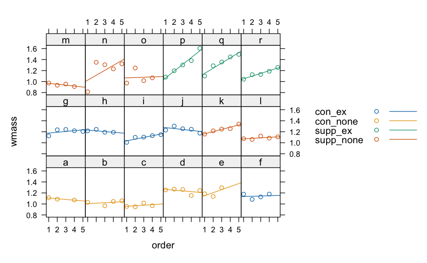

```r
xyplot(wmass~order|pair, groups=group, type=c("p","r"), auto.key=T, skrip)
```

```r
list_skrip <- lmList(wmass~order|pair, skrip, na.action=na.omit)
summary(list_skrip)
```

```
Call:
  Model: wmass ~ order | pair
   Data: skrip

Coefficients:
   (Intercept)
  Estimate Std. Error t value Pr(>|t|)
a    1.121     0.0865    12.9 1.31e-16
b    0.996     0.0853    11.7 4.50e-15
c    0.946     0.0865    10.9 4.05e-14
d    1.278     0.0741    17.2 3.36e-21
e    1.095     0.1079    10.1 4.27e-13
f    1.130     0.0865    13.1 9.91e-17
g    1.162     0.0741    15.7 1.27e-19
h    1.243     0.0865    14.4 3.23e-18
i    1.004     0.0741    13.6 2.63e-17
j    1.292     0.0741    17.4 2.21e-21
k    1.122     0.0741    15.1 4.74e-19
l    1.062     0.0741    14.3 3.55e-18
m    0.985     0.0865    11.4 1.05e-14
n    0.936     0.0741    12.6 3.12e-16
o    1.061     0.0865    12.3 8.62e-16
p    0.944     0.0741    12.7 2.34e-16
q    1.054     0.0741    14.2 4.70e-18
r    1.002     0.0741    13.5 2.89e-17
   order
  Estimate Std. Error t value Pr(>|t|)
a -0.01305     0.0327  -0.399 6.92e-01
b  0.00885     0.0239   0.370 7.13e-01
c  0.01056     0.0316   0.334 7.40e-01
d -0.01373     0.0223  -0.614 5.42e-01
e  0.05505     0.0500   1.102 2.77e-01
f  0.00492     0.0316   0.156 8.77e-01
g  0.01448     0.0223   0.648 5.20e-01
h -0.01304     0.0316  -0.413 6.82e-01
i  0.03093     0.0223   1.384 1.73e-01
j -0.01704     0.0223  -0.763 4.50e-01
k  0.04060     0.0223   1.817 7.61e-02
l  0.00922     0.0223   0.413 6.82e-01
m -0.01689     0.0316  -0.534 5.96e-01
n  0.08951     0.0223   4.005 2.35e-04
o  0.00582     0.0316   0.184 8.55e-01
p  0.12308     0.0223   5.508 1.78e-06
q  0.09463     0.0223   4.235 1.15e-04
r  0.04909     0.0223   2.197 3.34e-02

Residual standard error: 0.0707 on 44 degrees of freedom
```

some evidence of different slopes

### First model with random slopes and intercepts

```r
skrip1.lmer <- lmer(wmass~diet*exercise*order+(order|pair), REML=FALSE, skrip, na.action=na.omit)
```

### Second just random intercepts

```r
skrip2.lmer <- lmer(wmass~diet*exercise*order+(1|pair), REML=FALSE, skrip, na.action=na.omit)
```

### Test random slopes term

```r
rand(skrip1.lmer)
```

```
ANOVA-like table for random-effects: Single term deletions

Model:
wmass ~ diet + exercise + order + (order | pair) + diet:exercise + diet:order + exercise:order + diet:exercise:order
                        npar logLik  AIC  LRT Df Pr(>Chisq)
<none>                    12   81.2 -138
order in (order | pair)   10   79.8 -140 2.72  2       0.26
```

```r
anova(skrip2.lmer,skrip1.lmer)
```

```
Data: skrip
Models:
skrip2.lmer: wmass ~ diet * exercise * order + (1 | pair)
skrip1.lmer: wmass ~ diet * exercise * order + (order | pair)
            npar  AIC  BIC logLik deviance Chisq Df Pr(>Chisq)
skrip2.lmer   10 -140 -116   79.8     -160
skrip1.lmer   12 -138 -110   81.2     -162  2.72  2       0.26
```

```r
AICc(skrip2.lmer,skrip1.lmer)
```

|  | df | AICc |
| --- | --- | --- |
| skrip2.lmer | 10 | -136 |
| skrip1.lmer | 12 | -134 |

No strong evidence for random slopes so use random intercepts.

### Refit model with REML

```r
skrip3.lmer <- lmer(wmass~diet*exercise*order+(1|pair), REML=TRUE, skrip, na.action=na.omit)
```

Check residual plot - OK

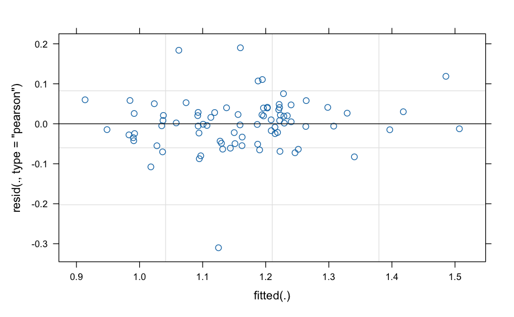

```r
plot(skrip3.lmer)
```

```r
summary(skrip3.lmer, ddf="Kenward-Roger")
```

```
Linear mixed model fit by REML. t-tests use Kenward-Roger's method ['lmerModLmerTest']
Formula: wmass ~ diet * exercise * order + (1 | pair)
   Data: skrip

REML criterion at convergence: -103

Scaled residuals:
   Min     1Q Median     3Q    Max
-4.139 -0.449  0.003  0.418  2.536

Random effects:
 Groups   Name        Variance Std.Dev.
 pair     (Intercept) 0.00846  0.0920
 Residual             0.00561  0.0749
Number of obs: 80, groups:  pair, 18

Fixed effects:
                      Estimate Std. Error       df t value Pr(>|t|)
(Intercept)            1.07029    0.02980 31.43799   35.91  < 2e-16 ***
diet1                  0.06294    0.02980 31.43799    2.11    0.043 *
exercise1              0.01065    0.02980 31.43799    0.36    0.723
order                  0.03261    0.00637 58.80375    5.12  3.5e-06 ***
diet1:exercise1        0.01830    0.02980 31.43799    0.61    0.544
diet1:order           -0.02923    0.00637 58.80375   -4.59  2.4e-05 ***
exercise1:order        0.01490    0.00637 58.80375    2.34    0.023 *
diet1:exercise1:order -0.01218    0.00637 58.80375   -1.91    0.061 .
---
Signif. codes:  0 ‘***’ 0.001 ‘**’ 0.01 ‘*’ 0.05 ‘.’ 0.1 ‘ ’ 1

Correlation of Fixed Effects:
            (Intr) diet1  exrcs1 order  dt1:x1 dt1:rd exrc1:
diet1       -0.115
exercise1    0.115 -0.145
order       -0.600  0.028 -0.028
diet1:xrcs1 -0.145  0.115 -0.115  0.084
diet1:order  0.028 -0.600  0.084 -0.009 -0.028
exercs1:rdr -0.028  0.084 -0.600  0.009  0.028 -0.137
dt1:xrcs1:r  0.084 -0.028  0.028 -0.137 -0.600  0.009 -0.009
```

```r
anova(skrip3.lmer, ddf="Kenward-Roger")
```

```
Type III Analysis of Variance Table with Kenward-Roger's method
                    Sum Sq Mean Sq NumDF DenDF F value  Pr(>F)
diet                0.0250  0.0250     1  31.4    4.46   0.043 *
exercise            0.0007  0.0007     1  31.4    0.13   0.723
order               0.1471  0.1471     1  58.8   26.21 3.5e-06 ***
diet:exercise       0.0021  0.0021     1  31.4    0.38   0.544
diet:order          0.1182  0.1182     1  58.8   21.06 2.4e-05 ***
exercise:order      0.0307  0.0307     1  58.8    5.47   0.023 *
diet:exercise:order 0.0205  0.0205     1  58.8    3.66   0.061 .
---
Signif. codes:  0 ‘***’ 0.001 ‘**’ 0.01 ‘*’ 0.05 ‘.’ 0.1 ‘ ’ 1
```

Get var comps with CIs

```r
skrip3.ci <- confint.merMod(skrip3.lmer, oldNames=FALSE)
```

```
Computing profile confidence intervals ...
```

```r
skrip3.vc <- (skrip3.ci)^2
print(skrip3.vc)
```

```
                         2.5 %   97.5 %
sd_(Intercept)|pair   2.95e-03 1.46e-02
sigma                 3.77e-03 7.64e-03
(Intercept)           1.03e+00 1.27e+00
diet1                 7.19e-05 1.38e-02
exercise1             1.92e-03 4.25e-03
order                 4.17e-04 2.02e-03
diet1:exercise1       1.32e-03 5.29e-03
diet1:order           1.73e-03 2.93e-04
exercise1:order       6.81e-06 7.34e-04
diet1:exercise1:order 5.91e-04 4.10e-08
```

#### Draw line plot

```r
skrip_stats <- summarySE(skrip,measurevar='wmass', groupvars= c('group','order'), na.rm=TRUE)
skrip_stats
```

| group | order | N | wmass | sd | se | ci |
| --- | --- | --- | --- | --- | --- | --- |
| con_ex | 1 | 5 | 1.151 | 0.0902 | 0.0403 | 0.1120 |
| con_ex | 2 | 5 | 1.193 | 0.0968 | 0.0433 | 0.1201 |
| con_ex | 3 | 5 | 1.184 | 0.0673 | 0.0301 | 0.0835 |
| con_ex | 4 | 5 | 1.192 | 0.0438 | 0.0196 | 0.0544 |
| con_ex | 5 | 3 | 1.176 | 0.0294 | 0.0170 | 0.0731 |
| con_none | 1 | 5 | 1.108 | 0.1195 | 0.0534 | 0.1483 |
| con_none | 2 | 4 | 1.110 | 0.1326 | 0.0663 | 0.2111 |
| con_none | 3 | 4 | 1.135 | 0.1675 | 0.0838 | 0.2666 |
| con_none | 4 | 4 | 1.059 | 0.0766 | 0.0383 | 0.1219 |
| con_none | 5 | 2 | 1.152 | 0.1317 | 0.0932 | 1.1836 |

[output cut: 10 more lines]

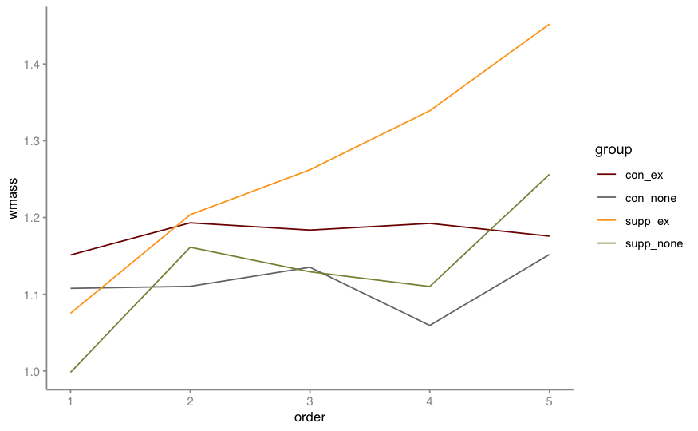

```r
ggplot(skrip_stats, aes(x=order, y=wmass, fill=group, colour=group))+
  geom_line()+
  theme_qk()+
  scale_colour_uchicago()
```